# Ecosystem Summary Heatmaps

Andrew Edwards

Last rendered on 23 October, 2026

## Customisable ecosystem summary heatmaps

```r
# load_all()    # for developers
library(pacea)  # for users
library(dplyr)
library(tibble)  # Else prints all of a tibble
library(ggplot2)
```

In the [buoy_anomalies](https://pbs-assess.github.io/pacea/vignettes/buoy_anomalies.html) vignette we showed how to make customisable heatmaps of the buoy sea-surface temperature data that are saved in pacea. They are in a format familiar to oceanographers, using prescribed climatologies and subsequent anomalies.

Here we show how to produce customisable heatmaps that include disparate types of ecosystem information, thus bringing together the various data objects in pacea. Importantly the user can choose:

- the types of ecosystem information to be included, tailored to their particular stock;
- the area over which spatial information is summarised.

The aim of pacea is to facilitate inclusion of ecosystem information in advice to fisheries management, such as stock assessments. Given the multitude of stocks in DFO’s Pacific Region, both in terms of the diversity of species and the many stock-specific spatial areas, we decided to create functions for user-customisable plots that easily summarise the relevant ecosystem information.

Expert knowledge can be used to suggest relevant ecosystem information to be used for a particular stock. Furthermore, the ease of generating the heatmaps can allow exploration, formulation of ideas, and quick hypothesis testing.

For comparing disparate types of ecosystem information, we calculate an annual index which is standardised (by subtracting the mean and dividing by the standard deviation across the time series; note that all years might not get shown in a plot). This is so that indices are all dimensionless and can be compared on equivalent scales, and shown on a single heatmap style plot.

As a general proof-of-concept example, let’s use some ecosystem information for the Strait of Georgia (SOG) that is in pacea. We create an index for each type of ecosystem information in turn and then make the plot. We just need to use `create_index()` multiple times to create the indices, and then `plot_indices()` to make the function (we will explain the functions in more detail later):

```r
# Average sea surface temperature in April from a buoy in the SOG
sst_buoy_halibut_bank_apr_index <- create_index(buoy_sst,
                                                months = 4,
                                                stn_id = "Halibut Bank")

# Large calanoid copepods in the SOG
calanoid_copepods_large_sog_index <- create_index(zooplankton_sog,
                                                  zooplankton_species_group =
                                                    "calanoid_copepods_large")

# Total zooplankton in the SOG
total_zooplankton_sog_index <- create_index(zooplankton_sog,
                                            zooplankton_species_group = "total_biomass")

# Annual age-2 herring recruitment in the SOG
herring_recruitment_sog_index <- create_index(herring_recruitment,
                                              herring_region = "SOG")

# Annual herring spawning biomass in the SOG
herring_biomass_sog_index <- create_index(herring_spawning_biomass,
                                          herring_region = "SOG")

# Annual population estimates of Harbour Seals in the SOG
harbour_seals_sog_index <- create_index(harbour_seals,
                                        seal_region = "SOG")
```

See the relevant vignettes and help files for details of the pacea objects used for each index. The first index is from the buoy sea surface temperature. Looking at the [buoy_anomalies](https://pbs-assess.github.io/pacea/vignettes/buoy_anomalies.html) vignette we have used the Halibut Bank buoy in the SoG, which has good timespans of data, and just pick April.

The `create_index()` function automatically creates an object of class `pacea_standardised_index`, no matter what type the ecosystem information is.

Now make the plot, manually basing the start year on the shortest of those (zooplankton data):

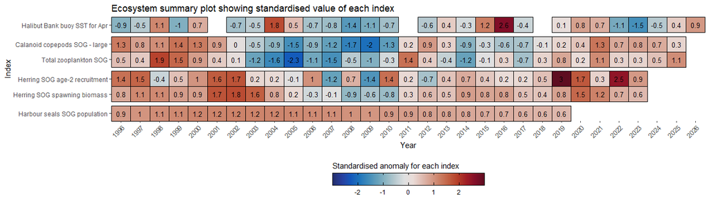

```r
plot_indices(sst_buoy_halibut_bank_apr_index,
             calanoid_copepods_large_sog_index,
             total_zooplankton_sog_index,
             herring_recruitment_sog_index,
             herring_biomass_sog_index,
             harbour_seals_sog_index,
             years = 1996:2026,
             gap_after = c("sst_buoy_halibut_bank_apr_index",
                           "total_zooplankton_sog_index",
                           "herring_biomass_sog_index"))
```

The first six arguments are the indices that we created above, and `years` restricts the plot to the years specified. To delineate different types of ecosystem information in the plot (e.g. here we have temperature, zooplankton, fish, mammals), we used the optional `gap_after` argument to add a small gap after the specified indices.

Each index is standardised over its full time series, and red for a year indicates above-average conditions, blue indicates below-average, with the black numbers giving the exact standardised anomaly (number of standard deviations above the mean), as used for the colour coding.

The restriction of the years being shown is why the seal index is always positive. By definition the mean of an index across its full time series is 0, and so the seal index must be negative earlier in the time series. A quick check of the absolute seal populations numbers confirms this, in that the population has indeed increased from the early years:

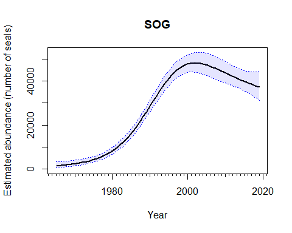

```r
plot(harbour_seals,
     region = "SOG")
```

Here are the details of what is in the buoy SST index object created above:

```r
sst_buoy_halibut_bank_apr_index
```

```
#> # A data frame: 35 × 4
#>    index                 year  value index_label
#>    <chr>                <dbl>  <dbl> <chr>
#>  1 halibut_bank_sst_apr  1992  1.15  Halibut Bank buoy SST for Apr
#>  2 halibut_bank_sst_apr  1993 -0.481 Halibut Bank buoy SST for Apr
#>  3 halibut_bank_sst_apr  1994 NA     Halibut Bank buoy SST for Apr
#>  4 halibut_bank_sst_apr  1995  0.583 Halibut Bank buoy SST for Apr
#>  5 halibut_bank_sst_apr  1996 -0.929 Halibut Bank buoy SST for Apr
#>  6 halibut_bank_sst_apr  1997 -0.533 Halibut Bank buoy SST for Apr
#>  7 halibut_bank_sst_apr  1998  1.14  Halibut Bank buoy SST for Apr
#>  8 halibut_bank_sst_apr  1999 -1.000 Halibut Bank buoy SST for Apr
#>  9 halibut_bank_sst_apr  2000  0.711 Halibut Bank buoy SST for Apr
#> 10 halibut_bank_sst_apr  2001 NA     Halibut Bank buoy SST for Apr
#> # ℹ 25 more rows
```

It is a tibble, with a value for each year, plus an `index` to refer to in code, and an `index_label` to use for the labels in the plot (these are repeated in each row, which just makes things easier at the plotting stage).

We can also choose multiple months. Note that `index` and `index_label` get automatically prescribed; examine the arguments and results for these three indices (for the default buoy, namely that in West Dixon Entrance):

```r
create_index(buoy_sst,
             months = 5)
```

```
#> # A data frame: 38 × 4
#>    index                        year  value index_label
#>    <chr>                       <dbl>  <dbl> <chr>
#>  1 west_dixon_entrance_sst_may  1989 NA     West Dixon Entrance buoy SST for May
#>  2 west_dixon_entrance_sst_may  1990 NA     West Dixon Entrance buoy SST for May
#>  3 west_dixon_entrance_sst_may  1991 -0.855 West Dixon Entrance buoy SST for May
#>  4 west_dixon_entrance_sst_may  1992  0.277 West Dixon Entrance buoy SST for May
#>  5 west_dixon_entrance_sst_may  1993  0.947 West Dixon Entrance buoy SST for May
#>  6 west_dixon_entrance_sst_may  1994  0.155 West Dixon Entrance buoy SST for May
#>  7 west_dixon_entrance_sst_may  1995  0.968 West Dixon Entrance buoy SST for May
#>  8 west_dixon_entrance_sst_may  1996 NA     West Dixon Entrance buoy SST for May
#>  9 west_dixon_entrance_sst_may  1997  0.594 West Dixon Entrance buoy SST for May
#> 10 west_dixon_entrance_sst_may  1998  0.589 West Dixon Entrance buoy SST for May
#> # ℹ 28 more rows
```

```r
create_index(buoy_sst,
             months = 5:6)
```

```
#> # A data frame: 38 × 4
#>    index                                year  value index_label
#>    <chr>                               <dbl>  <dbl> <chr>
#>  1 west_dixon_entrance_sst_may_and_jun  1989 NA     West Dixon Entrance buoy SST f…
#>  2 west_dixon_entrance_sst_may_and_jun  1990 NA     West Dixon Entrance buoy SST f…
#>  3 west_dixon_entrance_sst_may_and_jun  1991 -1.10  West Dixon Entrance buoy SST f…
#>  4 west_dixon_entrance_sst_may_and_jun  1992 NA     West Dixon Entrance buoy SST f…
#>  5 west_dixon_entrance_sst_may_and_jun  1993  1.25  West Dixon Entrance buoy SST f…
#>  6 west_dixon_entrance_sst_may_and_jun  1994  0.148 West Dixon Entrance buoy SST f…
#>  7 west_dixon_entrance_sst_may_and_jun  1995  0.218 West Dixon Entrance buoy SST f…
#>  8 west_dixon_entrance_sst_may_and_jun  1996 NA     West Dixon Entrance buoy SST f…
#>  9 west_dixon_entrance_sst_may_and_jun  1997  1.05  West Dixon Entrance buoy SST f…
#> 10 west_dixon_entrance_sst_may_and_jun  1998  0.427 West Dixon Entrance buoy SST f…
#> # ℹ 28 more rows
```

```r
create_index(buoy_sst,
             months = c(11, 12, 1, 2, 3))
```

```
#> # A data frame: 38 × 4
#>    index                               year  value index_label
#>    <chr>                              <dbl>  <dbl> <chr>
#>  1 west_dixon_entrance_sst_nov_to_mar  1989 NA     West Dixon Entrance buoy SST fo…
#>  2 west_dixon_entrance_sst_nov_to_mar  1990 NA     West Dixon Entrance buoy SST fo…
#>  3 west_dixon_entrance_sst_nov_to_mar  1991 -1.27  West Dixon Entrance buoy SST fo…
#>  4 west_dixon_entrance_sst_nov_to_mar  1992  0.508 West Dixon Entrance buoy SST fo…
#>  5 west_dixon_entrance_sst_nov_to_mar  1993  0.137 West Dixon Entrance buoy SST fo…
#>  6 west_dixon_entrance_sst_nov_to_mar  1994  1.17  West Dixon Entrance buoy SST fo…
#>  7 west_dixon_entrance_sst_nov_to_mar  1995 NA     West Dixon Entrance buoy SST fo…
#>  8 west_dixon_entrance_sst_nov_to_mar  1996 NA     West Dixon Entrance buoy SST fo…
#>  9 west_dixon_entrance_sst_nov_to_mar  1997 -1.10  West Dixon Entrance buoy SST fo…
#> 10 west_dixon_entrance_sst_nov_to_mar  1998  1.32  West Dixon Entrance buoy SST fo…
#> # ℹ 28 more rows
```

In the third example note how the months are specified from November to March - the year indicated is the year of the January.

Note that in the first example we have a value for 1992, but not in the second one. This must be because June 1992 does not have enough daily values for this particular buoy, which we can confirm from the raw data:

```r
filter(buoy_sst,
       stn_id == "C46205",   # default in create_index.pacea_buoy()
       date >= "1992-06-01",
       date <= "1992-06-30",
       !is.na(sst))
```

```
#> # A tibble: 6 × 3
#>   date       stn_id   sst
#>   <date>     <fct>  <dbl>
#> 1 1992-06-01 C46205  9.46
#> 2 1992-06-02 C46205  9.70
#> 3 1992-06-03 C46205  9.41
#> 4 1992-06-04 C46205 10.0
#> 5 1992-06-05 C46205 10.0
#> 6 1992-06-06 C46205 10.2
```

So there are only 6 daily SST values for this buoy in June 1992, and so an anomaly is not calculated for that month because the default is to require 15 daily SST values in a month. We could force an anomaly to be calculated by changing the arguments `min_days_per_month` (default 15) and `max_consecutive_missing_days` (default 6) that get passed onto `calculate_anomalies.pacea_buoy()`:

```r
create_index(buoy_sst,
             months = 5:6,
             min_days_per_month = 6,
             max_consecutive_missing_days = 24)
```

```
#> # A data frame: 38 × 4
#>    index                                year   value index_label
#>    <chr>                               <dbl>   <dbl> <chr>
#>  1 west_dixon_entrance_sst_may_and_jun  1989 NA      West Dixon Entrance buoy SST …
#>  2 west_dixon_entrance_sst_may_and_jun  1990 NA      West Dixon Entrance buoy SST …
#>  3 west_dixon_entrance_sst_may_and_jun  1991 -1.21   West Dixon Entrance buoy SST …
#>  4 west_dixon_entrance_sst_may_and_jun  1992 -0.634  West Dixon Entrance buoy SST …
#>  5 west_dixon_entrance_sst_may_and_jun  1993  1.26   West Dixon Entrance buoy SST …
#>  6 west_dixon_entrance_sst_may_and_jun  1994  0.0977 West Dixon Entrance buoy SST …
#>  7 west_dixon_entrance_sst_may_and_jun  1995  0.170  West Dixon Entrance buoy SST …
#>  8 west_dixon_entrance_sst_may_and_jun  1996  0.721  West Dixon Entrance buoy SST …
#>  9 west_dixon_entrance_sst_may_and_jun  1997  1.04   West Dixon Entrance buoy SST …
#> 10 west_dixon_entrance_sst_may_and_jun  1998  0.389  West Dixon Entrance buoy SST …
#> # ℹ 28 more rows
```

thus giving an index value for 1992, given these definitions (which we do not recommend, but are showing as examples to help understanding, and to show that arguments get correctly passed onto further functions).

For any type of pacea object, check the exact calculations and further options by checking `class(object)` and then `?create_index.<class>`. For example `?create_index.pacea_buoy` for the `buoy_sst` data.

## OISST spatiotemporal data

We now create various indices from the Optimally Interpolated Sea Surface Temperature (OISST) spatiotemporal data, that are described in oisst.html. An index is a single standardised value for each year, and for SST would be based on the mean anomalies over a given area.

It is first best to plot the spatial anomalies for the area of interest, to verify the area and understand what is going on. We will then calculate an index directly from the anomalies list, or directly from `create_index(oisst_month)` with various options.

First, let’s look at the full domain of the OISST data and calculate annual anomalies and do the default plot (which is for the most recent month of data):

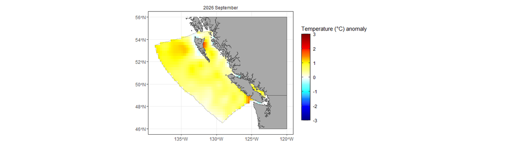

```r
oisst_anomalies <- calculate_anomalies(oisst_month)

plot(oisst_anomalies)
```

The `oisst_anomalies` list object (of class `pacea_oisst_anomalies_list`) contains the climatology for each month-location combination, plus the anomalies relative to those for each year-month-location combination, plus the `climatology_years` used:

```r
oisst_anomalies
```

```
#> $climatology
#> Simple feature collection with 11100 features and 4 fields
#> Geometry type: POINT
#> Dimension:     XY
#> Bounding box:  xmin: -138.625 ymin: 46.625 xmax: -123.125 ymax: 54.625
#> Geodetic CRS:  WGS 84
#> # A tibble: 11,100 × 5
#>    month clim_value clim_sd clim_n          geometry
#>    <dbl>      <dbl>   <dbl>  <int>       <POINT [°]>
#>  1     1       9.51   0.842     30 (-129.125 46.625)
#>  2     1       9.33   0.888     30 (-129.625 46.875)
#>  3     1       9.36   0.862     30 (-129.375 46.875)
#>  4     1       9.38   0.836     30 (-129.125 46.875)
#>  5     1       9.38   0.806     30 (-128.875 46.875)
#>  6     1       9.37   0.770     30 (-128.625 46.875)
#>  7     1       9.17   0.900     30 (-130.125 47.125)
#>  8     1       9.19   0.887     30 (-129.875 47.125)
#>  9     1       9.22   0.866     30 (-129.625 47.125)
#> 10     1       9.23   0.840     30 (-129.375 47.125)
#> # ℹ 11,090 more rows
#>
#> $anomalies
#> Simple feature collection with 500425 features and 7 fields
#> Geometry type: POINT
#> Dimension:     XY
#> Bounding box:  xmin: -138.625 ymin: 46.625 xmax: -123.125 ymax: 54.625
#> Geodetic CRS:  WGS 84
#> # A tibble: 500,425 × 8
#>     year month   sst start_date end_date   clim_value   anom
#>  * <dbl> <dbl> <dbl> <date>     <date>          <dbl>  <dbl>
#>  1  1981     9  16.4 1981-09-01 1981-09-30       16.7 -0.339
#>  2  1981    10  14.3 1981-10-01 1981-10-31       15.2 -0.921
#>  3  1981    11  12.7 1981-11-01 1981-11-30       12.8 -0.124
#>  4  1981    12  10.2 1981-12-01 1981-12-31       10.7 -0.456
#>  5  1981     9  16.4 1981-09-01 1981-09-30       16.6 -0.179
#>  6  1981    10  14.2 1981-10-01 1981-10-31       15.0 -0.750
#>  7  1981    11  12.4 1981-11-01 1981-11-30       12.6 -0.180
#>  8  1981    12  10.0 1981-12-01 1981-12-31       10.5 -0.490
#>  9  1981     9  16.4 1981-09-01 1981-09-30       16.6 -0.231
#> 10  1981    10  14.3 1981-10-01 1981-10-31       15.0 -0.680
#> # ℹ 500,415 more rows
#> # ℹ 1 more variable: geometry <POINT [°]>
#>
#> $climatology_years
#>  [1] 1991 1992 1993 1994 1995 1996 1997 1998 1999 2000 2001 2002 2003 2004 2005
#> [16] 2006 2007 2008 2009 2010 2011 2012 2013 2014 2015 2016 2017 2018 2019 2020
#>
#> $climatology_time
#> [1] "month"
#>
#> attr(,"class")
#> [1] "pacea_oisst_anomalies_list" "list"
```

We can specify months and years in a plot, chosen here to show the marine heatwave forming in 2014:

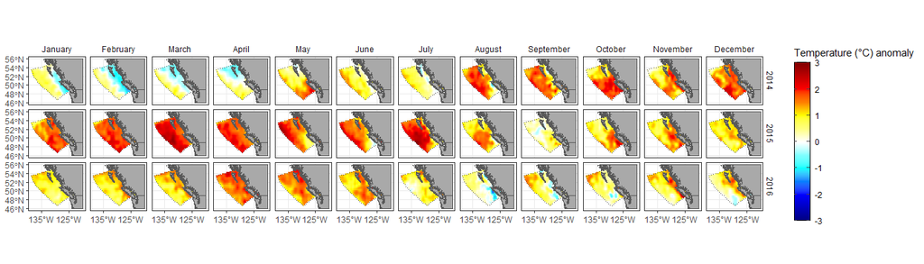

```r
plot(oisst_anomalies,
     months = 1:12,
     years = 2014:2016,
     x_axis_labels = c(-135, -125)) # specify the x-axis labels to be shown
```

We can create an index of the mean anomaly each year averaged over, say, Apr-Jun, over the full domain shown (which is Canada’s Exclusive Economic Zone):

```r
oisst_eez_apr_jun_index <- create_index(oisst_anomalies,
                                        months = 4:6,
                                        index_name =
                                          "oisst_apr_to_jun_over_eez",
                                        index_label = "OISST for Apr to Jun over EEZ")
oisst_eez_apr_jun_index
```

```
#> # A data frame: 45 × 4
#>    index                      year  value index_label
#>    <chr>                     <dbl>  <dbl> <chr>
#>  1 oisst_apr_to_jun_over_eez  1982 -1.11  OISST for Apr to Jun over EEZ
#>  2 oisst_apr_to_jun_over_eez  1983  1.25  OISST for Apr to Jun over EEZ
#>  3 oisst_apr_to_jun_over_eez  1984 -0.241 OISST for Apr to Jun over EEZ
#>  4 oisst_apr_to_jun_over_eez  1985 -1.13  OISST for Apr to Jun over EEZ
#>  5 oisst_apr_to_jun_over_eez  1986 -0.623 OISST for Apr to Jun over EEZ
#>  6 oisst_apr_to_jun_over_eez  1987 -0.392 OISST for Apr to Jun over EEZ
#>  7 oisst_apr_to_jun_over_eez  1988 -1.10  OISST for Apr to Jun over EEZ
#>  8 oisst_apr_to_jun_over_eez  1989 -0.340 OISST for Apr to Jun over EEZ
#>  9 oisst_apr_to_jun_over_eez  1990 -0.367 OISST for Apr to Jun over EEZ
#> 10 oisst_apr_to_jun_over_eez  1991 -1.02  OISST for Apr to Jun over EEZ
#> # ℹ 35 more rows
```

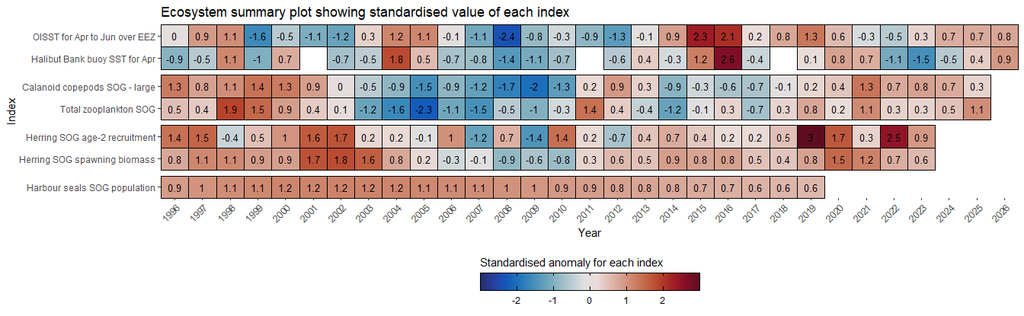

```r
plot_indices(oisst_eez_apr_jun_index,
             sst_buoy_halibut_bank_apr_index,
             calanoid_copepods_large_sog_index,
             total_zooplankton_sog_index,
             herring_recruitment_sog_index,
             herring_biomass_sog_index,
             harbour_seals_sog_index,
             years = 1996:2026,
             gap_after = c("sst_buoy_halibut_bank_apr_index",
                           "total_zooplankton_sog_index",
                           "herring_biomass_sog_index"))
```

This is showing the proof of concept, in that, we can easily compare the mean SST anomaly across the whole EEZ over April to June with the buoy SST mean anomaly for April, at one location (the point being you can define an index however you like and easily compare it).

In practice, we likely want to restrict an index (and annual summary figure) to a specific spatial region, and also specific months.

### Restricting an index over a spatial area

To create anomalies for a specific area, such as Pacific Marine Fisheries Area 126, again showing the heatwave progressing

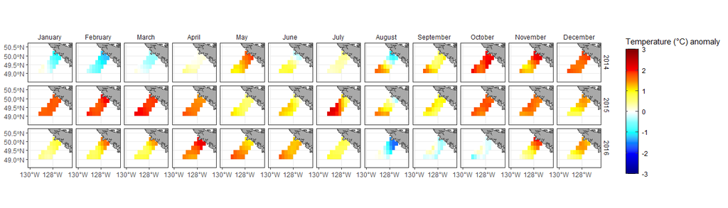

```r
oisst_anomalies_area_126 <- calculate_anomalies(oisst_month,
                                                area = pfma_area_126_temp)

plot(oisst_anomalies_area_126,
     months = 1:12,
     years = 2014:2016,
     restrict_plot = TRUE,          # restrict the plot to the area of the anomalies
     buffer_proportion = 0.6,       # add a buffer proportion to zoom out a bit
     x_axis_labels = c(-130, -128)) # specify the x-axis labels to be shown
```

(Some of those settings are hard to automate with multiple panels, so users may need to tweak the options; also `pfma_area_126_temp` is a temporary data object in pacea and will change names when we import many fisheries management areas).

For investigating plots (rather than doing analyses), we can also simply use the `area` argument when plotting the full `oisst_anomalies`, giving the same plot as above (so we have not shown it again here):

```r
plot(oisst_anomalies,
     area = pfma_area_126_temp,
     months = 1:12,
     years = 2014:2016,
     restrict_plot = TRUE,
     buffer_proportion = 0.6,
     x_axis_labels = c(-130, -128))
```

To calculate the index for Area 126 in April (the default), and give it an appropriate name and label:

```r
oisst_area_126_apr_index <- create_index(oisst_anomalies_area_126,
                                         index_name = "oisst_apr_area_126",
                                         index_label = "OISST in Apr over Area 126")   # April is the default

oisst_area_126_apr_index
```

```
#> # A data frame: 45 × 4
#>    index               year   value index_label
#>    <chr>              <dbl>   <dbl> <chr>
#>  1 oisst_apr_area_126  1982 -0.424  OISST in Apr over Area 126
#>  2 oisst_apr_area_126  1983  1.70   OISST in Apr over Area 126
#>  3 oisst_apr_area_126  1984 -0.241  OISST in Apr over Area 126
#>  4 oisst_apr_area_126  1985 -1.05   OISST in Apr over Area 126
#>  5 oisst_apr_area_126  1986 -0.0524 OISST in Apr over Area 126
#>  6 oisst_apr_area_126  1987  0.203  OISST in Apr over Area 126
#>  7 oisst_apr_area_126  1988 -0.878  OISST in Apr over Area 126
#>  8 oisst_apr_area_126  1989 -0.699  OISST in Apr over Area 126
#>  9 oisst_apr_area_126  1990 -0.153  OISST in Apr over Area 126
#> 10 oisst_apr_area_126  1991 -0.708  OISST in Apr over Area 126
#> # ℹ 35 more rows
```

For comparison we can also calculate the mean sea surface temperature for April from a buoy within area 126

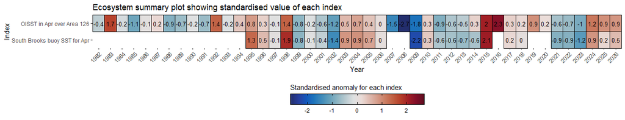

```r
sst_buoy_south_brooks_apr_index <- create_index(buoy_sst,
                                                months = 4,
                                                stn_id = "South Brooks")
plot_indices(oisst_area_126_apr_index,
             sst_buoy_south_brooks_apr_index)
```

This shows that the two different indices representing SST are fairly correlated but not exactly the same, as expected.

It makes sense to restrict the plot to 1995 onwards when we have both types of data. You can either restrict the years in the plot, or recalculate the OISST anomalies from 1995 onwards. Note how these give slightly different figures; restricting the plot:

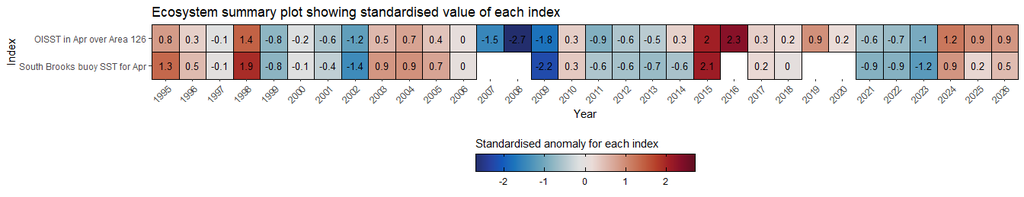

```r
plot_indices(oisst_area_126_apr_index,
             sst_buoy_south_brooks_apr_index,
             years = 1995:2026)
```

or recalculate a restricted index:

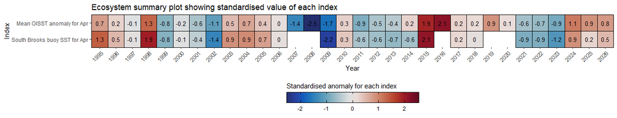

```r
oisst_area_126_apr_from_1995_index <-
  create_index(oisst_anomalies_area_126,
               years = 1995:2026)

plot_indices(oisst_area_126_apr_from_1995_index,
             sst_buoy_south_brooks_apr_index)
```

You can also create an index directly from the `oisst_month` data, for which the anomalies are calculated internally. Though it seems better to calculate the full spatial anomalies for your area to take a look at them first, as we did above. Nevertheless, `create_index()` will work directly on `oisst_month`, with the `area` option, giving the same result as above

```r
oisst_area_126_apr_index_directly <- create_index(oisst_month,
                                                  area = pfma_area_126_temp,
                                                  index_name =
                                                    "oisst_apr_area_126",
                                                  index_label = "OISST in Apr over Area 126")

expect_equal(oisst_area_126_apr_index,
             oisst_area_126_apr_index_directly)
```

We can also show every month of a spatially averaged anomaly in a heatmap style plot, like in the [buoy_anomalies](https://pbs-assess.github.io/pacea/vignettes/buoy_anomalies.html) vignette. This nicely summarises the many spatial maps (which can’t all easily digested by a reader) into one plot. Note that these are NOT annual indices:

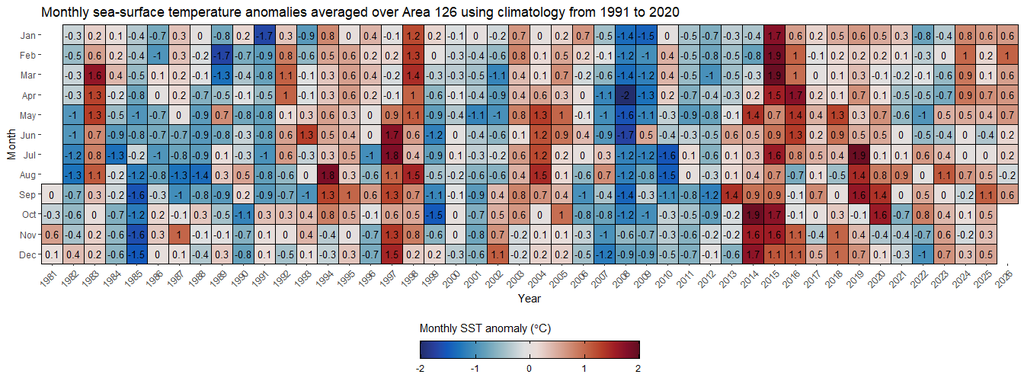

```r
plot(oisst_anomalies_area_126,
     heatmap_style = TRUE,
     area_name = "Area 126")
```

You can just do a few months of interest:

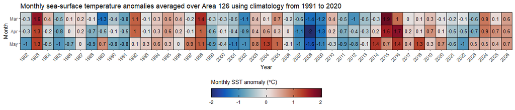

```r
plot(oisst_anomalies_area_126,
     heatmap_style = TRUE,
     area_name = "Area 126",
     months = 3:5)
```

See the code of the vignette (specifically the chunk headers) to see how to get the figure sizes looking good; these are not automated in the functions.

If you have read this far then you deserve to learn about another, lesser known, spatial area available in pacea.

[figure not shown]

```r
oisst_anomalies_sasquatch <- calculate_anomalies(oisst_month,
                                                 area = sasquatch)

plot(oisst_anomalies_sasquatch,
     restrict_plot = TRUE,
     buffer_proportion = 1,
     area_outline = sasquatch)
```

In average years, the sasquatch appears to hide away, only coming out when it’s warm or cold:

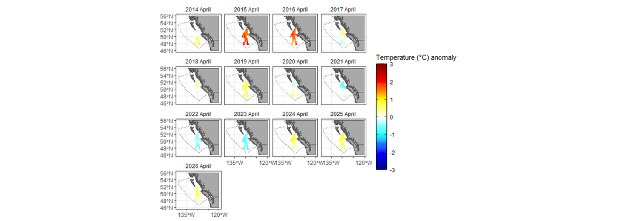

```r
plot(oisst_anomalies_sasquatch,
     months = 4,
     years = 2014:2026)
```

And we can create a new index, and see how it compares to that above for Area 126:

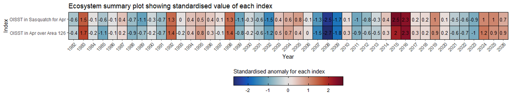

```r
oisst_sasquatch_apr_index <- create_index(oisst_anomalies_sasquatch,
                                months = 4,
                                index_label = "OISST in Sasquatch for Apr")

plot_indices(oisst_sasquatch_apr_index,
             oisst_area_126_apr_index)
```

## Climatological and oceanographic indices

For details of the climatological and oceanographic indices available in pacea see the [indices](https://pbs-assess.github.io/pacea/vignettes/indices.html) vignette. For example, we have developed a heatmap style that is particularly useful for understanding the emergence of El Niño (see vignette for more details), with shades of blue representing La Niña conditions, grey representing neutral, and shades of red representing El Niño:

```r
plot(oni,
     years = 1980:2026,
     neutral_oni_one_colour = TRUE,
     heatmap_style = TRUE)
```

[output not shown]

```r
oni_index_nov_jan <- create_index(oni,
                                  months = c(11, 12, 1))
```

We can see if that looks to correlate with the previously calculated index of temperature in Area 126, off the west coast of Vancouver Island:

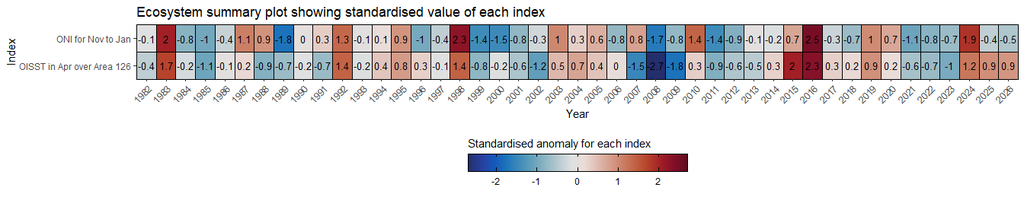

```r
plot_indices(oni_index_nov_jan,
             oisst_area_126_apr_index,
             years = 1982:2026)
```

(Note that the standardised ONI here is standardised like all variables in such a plot, as noted in the title, so values are not the same as for usually-defined ONI).

The red and blues generally match up, although there are some exceptions. The correlation coefficient is

```r
cor(filter(oni_index_nov_jan, year >= 1982)$value,
    oisst_area_126_apr_index$value) %>% round(2)
```

```
#> [1] 0.68
```

Interestingly, the averaged temperature over Area 126 (second row) for 2026 is 0.9 – only in 2025 and 2026 has it been >0.5 when the standardised ONI the previous Nov to Jan is negative (blue). So coming into an El Niño for 2026-2027, the water is already relatively warm. This shows the sort of hypotheses you can start looking into and trying to understand. And because we have the values available, we can make a quick plot to demonstrate this last point:

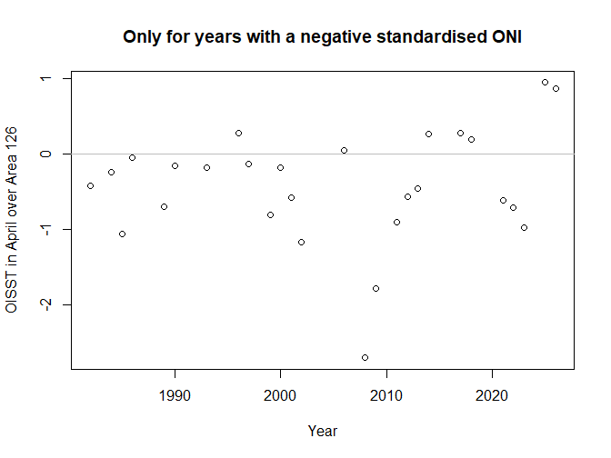

```r
# Values of the standardised ONI that are negative:
oni_index_neg <- filter(oni_index_nov_jan,
                        year >= 1982,     # when OISST data start
                        value <= 0)
# Corresponding Area 126 April mean OISST for those years:
oisst_area_126_apr_oni_neg <- filter(oisst_area_126_apr_index,
                                     year %in% oni_index_neg$year)

plot(oisst_area_126_apr_oni_neg$year,
     oisst_area_126_apr_oni_neg$value,
     xlab = "Year",
     ylab = "OISST in April over Area 126",
     main = "Only for years with a negative standardised ONI")
abline(h = 0, col = "grey")
```

We can also look at potential correlations with the other temperature indices we calculated above (for a buoy and for the whole EEZ):

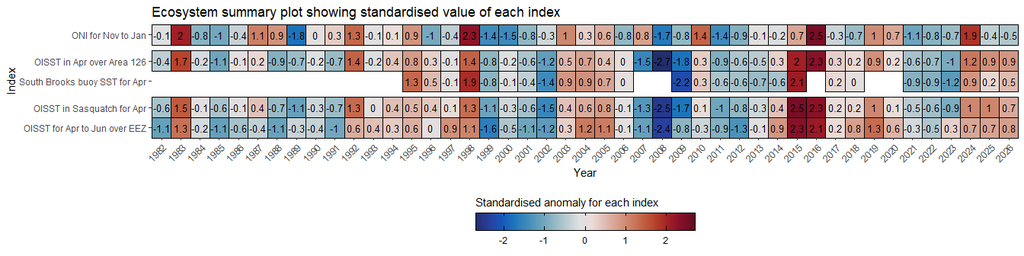

```r
plot_indices(oni_index_nov_jan,
             oisst_area_126_apr_index,
             sst_buoy_south_brooks_apr_index,
             oisst_sasquatch_apr_index,
             oisst_eez_apr_jun_index,
             years = 1982:2026,
             gap_after = c("oni_index_nov_jan",
                           "sst_buoy_south_brooks_apr_index"))
```

For the full EEZ (bottom row), the signal is not as strong.

The earlier point above about ONI and Area 126 in 2025 and 2026 does not show really show up in a simple plot (the years in question are highlighted in red, but otherwise would not really stand out; to be improved with a general phase plot function):

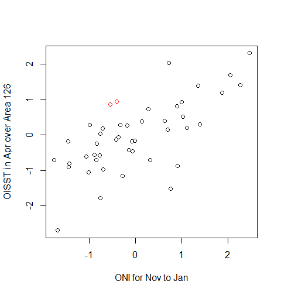

```r
plot(filter(oni_index_nov_jan, year >= 1982)$value,
     oisst_area_126_apr_index$value,
     xlab = oni_index_nov_jan$index_label[1],
     ylab = oisst_area_126_apr_index$index_label[1])
points(filter(oni_index_nov_jan,
              year %in% 2025:2026)$value,
       filter(oisst_area_126_apr_index,
              year %in% 2025:2026)$value,
       col = "red")
```

This demonstrates the usefulness of the heatmap-style plot.

The `create_index()` function works on all the climatological and oceanographic indices in pacea (PDO, NPGO, etc.; see `pacea_indices`) and so that plus `plot_indices()` could be used to compare and help understand the relationships between the various indices. An exercise for the reader.

## Biogeochemical model outputs

We have not yet tested or worked on extracting indices from the BCCM and HOTSSea model outputs. Coming soon. The OISST functions should help but will need slight adapting. TODO

## Tailoring for a specific stock

In the [2025 Pacific Hake stock assessment](https://s3.amazonaws.com/media.fisheries.noaa.gov/2025-02/Status-Pacific-Hake-whiting-US-and-Canadian-waters-2025.pdf) we presented a hake-specific ecosystem summary as a first step to providing an operational summary of relevant ecosystem information regarding the coastwide Pacific Hake stock (from California to British Columbia). The ecosystem summary was updated in the [2026 assessment](https://www.fisheries.noaa.gov/s3/2026-02/hake-assessment-2026.pdf), with about half of the variables shown coming directly from pacea.

Without going into too much detail (see the assessments), we now develop an ecosystem summary heatmap of some of the ecosystem influences on Pacific Hake recruitment (age-0 individuals) found by [Vestfals et al. (2023)](https://onlinelibrary.wiley.com/doi/full/10.1111/fog.12634). This will improve upon the time-series style plots used in the 2025 and 2026 assessments.

We show five indices from pacea:

| Definition | Effect on recruitment | Expectation for an increase in the index |
| --- | --- | --- |
| Pacific Decadal Oscillation during preconditioning (Apr-Sep) | Indicator of basin-scale processes, negative phase linked to higher productivity and improved adult condition | $\downarrow$ recruitment the following year |
| North Pacific Gyre Oscillation during preconditioning (Apr-Sep) | Indicator of basin-scale processes, positive phase linked to higher nutrient concentrations and productivity, and improved adult condition | $\uparrow$ recruitment the following year |
| North Pacific Current Bifurcation Index | Northward-shifted bifurcation leads to increased advection of prey southwards, leading to poorer feeding conditions off British Columbia, Washington, and Oregon, and reduced adult condition | $\downarrow$ recruitment the following year |
| Pacific Herring spawning biomass off the west coast of Vancouver Island | Increased competition with herring on summer feeding grounds leads to poorer feeding conditions and reduced adult condition | $\downarrow$ recruitment the following year |
| Biomass of age-1 Pacific Hake | Age-1 hake predate on pelagic juveniles (roughly Apr-Sep) | $\downarrow$ recruitment that year |

We introduce two new options in `plot_indices()`:

- lagging an index when the influence of the index is on the following year’s hake recruitment (as seen for four of the indices above);
- flipping the colour scale when a negative index is expected to positively enhance hake recruitment (as seen for four of the indices above).

So create the relevant indices from pacea objects and then make the plot:

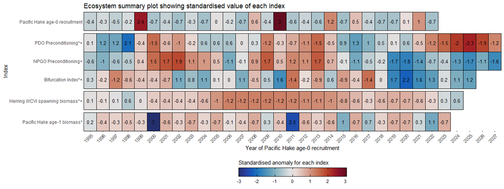

```r
hake_assessment_year <- 2026
hake_recruitment_final_year_to_use <- 2022  # final years removed as not
            # estimated by data, depends on the model assumptions
age_1_hake_final_year_to_use <- hake_recruitment_final_year_to_use + 1

hake_recruitment_index <- create_index(
  filter(hake_recruitment,
         year <= hake_recruitment_final_year_to_use),
  index_name = "hake_recruitment",
  index_label = "Pacific Hake age-0 recruitment")

start_year <- hake_recruitment_index$year[1]

pdo_index <- create_index(filter(pdo,
                                 year >= start_year),
                          months = 4:9,
                          index_name = "pdo_preconditioning",
                          index_label = "PDO Preconditioning")

npgo_index <- create_index(filter(npgo,
                                 year >= start_year),
                          months = 4:9,
                          index_name = "npgo_preconditioning",
                          index_label = "NPGO Preconditioning")

bi_index <- create_index(bi,
                         index_label = "Bifurcation Index")

herring_biomass_wcvi_index <- create_index(filter(herring_spawning_biomass,
                                                  year >= start_year),
                                           herring_region = "WCVI",
                                           index_name =
                                             "herring_spawning_biomass_wcvi")

hake_age_1_index <- create_index(filter(hake_total_biomass_age_1,
                                        year <= age_1_hake_final_year_to_use),
                                 index_name = "hake_age_1_total_biomass",
                                 index_label = "Pacific Hake age-1 biomass")


plot_indices(hake_recruitment_index,
             pdo_index,
             npgo_index,
             bi_index,
             herring_biomass_wcvi_index,
             hake_age_1_index,
             years = 1995:2027,    # else a bit unwieldy to see
             gap_after = c("hake_recruitment_index",
                           "bi_index",
                           "herring_biomass_wcvi_index"),
             flip = c("pdo_index",
                      "bi_index",
                      "herring_biomass_wcvi_index",
                      "hake_age_1_index"),
             shift = c("pdo_index",
                       "npgo_index",
                       "bi_index",
                       "herring_biomass_wcvi_index"))
```

The top row shows the index of hake recruitment, with the other rows showing some of the indices that are expected to influence hake recruitment. For the indices annotated with $^*$, the numbers show the index but the colours are flipped, such that red is always ‘good for recruitment’ and blue is bad; these indices are the four with a $\downarrow$ in the final column of the table.

For the four indices that the effect of the index is expected on the *following* year’s hake recruitment, the plotted index is shifted by a year and this is indicated by a `+` symbol annotated to the index label. This is so that the x-axis represents the year of the hake recruitment; so all the influences on, say, 1995 recruitment are in the 1995 column (even if the index is calculated on 1994 data), and red basically implies good for hake and blue implies not good.

To briefly interpret some of the results, for the very large 1999 year class (high 1999 hake recruitment), the five indices imply slightly favourable conditions, as they are all coloured red. For the very large 2010 class four of them do, which is the same for the not-so-large (but still way above average) 2008 and 2014 classes. For the strong 2016 and 2021 age classes, only three and two indices indicate favourable conditions, respectively. Thus, as expected, such influences are not definitive.

Note that the latest estimate of hake recruitment is for 2022 (at the original time of writing, October 2026), but we already have estimates of all the other indices for 2023, and some of them for later years. Thus, if a good relationship holds, we have some information for recent recruitments that we do not yet have estimates for from the stock assessment model.

Also, note that we already have estimates of the relevant indices derived from PDO and NPGO for 2027, because the Apr-Sep 2026 values are available now, and the influence of these is expected on the 2027 hake recruitment (so they appear in the 2027 column).

More work is needed regarding interpretation, but the point here is to demonstrate the functionality. In the hake assessment we also showed indices abstracted from outputs of the Global Ocean Physics Reanalysis (GLORYS12V1) product, which is a global ocean eddy-resolving oceanographic model. These looked at, for example, mixed-layer depths and strength of currents that affect eggs and larvae.